# PYTHON WITH BABA AAMMAR

### OPERATORS

```python
print(2+2)  #adddition
print(3*4)  #multiplication operator
print(6-4)  #Substraction Operator
print(9/3)  #Devision Operator / if we need floating value
print(9//3) #if we need complete whole value
print(16%4) #Modulous Operator / if e need reminder
print(3**2) #Exponents / if we want power of some value

print(2+3*4-6/9**4)
```

```
4
12
2
3.0
3
0
9
13.999085505258344
```

# PEMDAS

- paranthesis, Exponents , Multiliplication , Devision, Addition ,Subsrtraction
- Left to Right For Multiliplication Devision & Addition Subsrtraction

# String

```python
print("hello world")
print('Hello world')
print('''hey world''')
```

```
hello world
Hello world
hey world
```

# Types of Strings

# (' ') single Quotes

# (" ") Double Quotes

# (''' ''') Tripple Quotes

# VARIABLE

```python
x=34                   #Integer Variable
y=5.0                  #float Variable
z="Ammar is my guru"   #String Variable
print(x)
print(y)
print(z)
```

```
34
5.0
Ammar is my guru
```

# Rules to assign variable

- The variable should contain Variables numbers or underscore
- Donot start with numbers
- Spaces are not allow
- Donot use functional keywords of pyhon e.g dont use (break, dell , test etc)
- Short and descriptive
- Case Senstivity (lower case ,upper case should used)

```python
persons_in_meeting=4
persons_in_meeting="8 females & 4 males"
print(persons_in_meeting)

# type(persons_in_meeting)
print(type(persons_in_meeting))
```

```
8 females & 4 males
<class 'str'>
```

# input_function

```python
persons=4
print(persons)

# #input function
persons=input("how many persons in room  ?  ")
print( persons + " peoples are in the room")

# #2nd way of input function
persons=input("How many persons in room  ? ")
greeting="ASSALAM U ALAKKIM all"
print( greeting , persons )

# #an other stage of 2nd type
persons=input("How many persons in room  ? ")
print("Assalam u alaikum all ",persons )

#3rd srage input function
persons=input("how many persons in room  ?  ")
Age=input("Whats your all average age ?")
greeting="ASSALAM U ALAKKIM all "
print(greeting ,persons , "you all are still young" )
```

```
4
how many persons in room  ?  5
5 peoples are in the room
How many persons in room  ? 6
ASSALAM U ALAKKIM all 6
How many persons in room  ? 6
Assalam u alaikum all  6
how many persons in room  ?  6
Whats your all average age ?6
ASSALAM U ALAKKIM all  6 you all are still young
```

# Logical Operators

```python
 #either true OR False

#less than                  <
#less than equal to         <=
#Greater than               >
#Greater than equal to      >=
#Equal to                   ==
#Not Equal To               !=
#Assignment operator        =  #used in variables


#is 5 equal to 5?
print(5==5)
print(5<6)
print(5<=6)
print(6>5)
print(6>=5)
print(5!=5)

#EXAMPLE
Mohsin_age=5
School_age=5
print(Mohsin_age==School_age)

#anyother stage with input

Mohsin_age=input("Whats your age? ")
School_age=5       # false horha hay q ky type string hochki hay
print(type(Mohsin_age))   #class Type String hue v hay
Mohsin_age=int(Mohsin_age)
print(type(Mohsin_age))    #class type changed to int
print(Mohsin_age==School_age)
```

```
True
True
True
True
True
False
True
Whats your age? 5
<class 'str'>
<class 'int'>
True
```

# FUNCTIONS

```python
def school_calculator(Mohsin_age , text):
    if Mohsin_age==5:
         print("Mohsin is eligible for School")
    elif Mohsin_age>=5:
         print("Mohsin is also eligible for School")
    elif Mohsin_age<=4:
         print("You soul care abou your child")
    else:
     print("Mohsin is not eligible for School")
school_calculator(3,"mohsin")
```

```
You soul care abou your child
```

# Type connversion

```python
Mohsin_age=input("Whats your age? ")
print(Mohsin_age ,type(float(Mohsin_age)))
```

[output not shown]

# while for

```python
a=24
while a <=30:
    print(a)
    a=a+1


x=11
while x<=23:
    print(x)
    x=x+1


for x in range(1,4):
    print(x)
```

```
24
25
26
27
28
29
30
11
12
13
14
15
16
17
18
19
20
21
22
23
1
2
3
```

# if else Statement

```python
Mohsin_age=2
required_age_for_school=5
if Mohsin_age==required_age_for_school:
    print("Mohsin is eligible for School")
elif Mohsin_age>=required_age_for_school:
    print("Mohsin is also eligible for School")
elif Mohsin_age<=4:
    print("You soul care abou your child")
else:
    print("Mohsin is not eligible for School")
```

```
You soul care abou your child
```

# libraries import

```python
import math
print(math.pi)

import statistics
x=[23,54,7,767,87,5,6]
print(statistics.mean(x))
```

```
3.141592653589793
135.57142857142858
```

# indexing

```python
a="samosa pakora"
a
```

```
'samosa pakora'
```

```python
a[0]
```

```
's'
```

```python
a[1]
```

```
'a'
```

```python
a[3]
```

```
'o'
```

## To find leght

```python
len(a)
```

```
13
```

# last character is exclusive

```python
a[13]
```

```
---------------------------------------------------------------------------
IndexError                                Traceback (most recent call last)
<ipython-input-6-cf66ef2dd365> in <module>
----> 1 a[13]

IndexError: string index out of range
```

```python
a[0:6]
```

```
'samosa'
```

```python
a[7:14]
```

```
'pakora'
```

```python
len(a)
```

```
13
```

```python
a[-1]
```

```
'a'
```

```python
a[-3]
```

```
'o'
```

```python
a[-6:13]
```

```
'pakora'
```

# String Methods

```python
food="briyani"
food
```

```
'briyani'
```

```python
len(food)
```

```
7
```

- Ager main food kay bad dot likhnay kay bad tab dbnaonga to options show hngay

```python
food.capitalize()       # capitalizer first letter
```

```
'Briyani'
```

```python
food.upper()            # capitalize every letter
```

```
'BRIYANI'
```

```python
food.lower()            # lower letter
```

```
'briyani'
```

```python
food.replace("b","sh")  # Replace letter
```

```
'shriyani'
```

# counting a specific letter

```python
food.count("a")
```

```
1
```

```python
food.count("i")
```

```
2
```

# finding an index number in string

```python
food.find("a")
```

```
4
```

```python
# spliting a String
Menue="samosa & pakora , briyan & karahi , fibo & fish"
Menue
```

```
'samosa & pakora , briyan & karahi , fibo & fish'
```

```python
Menue.split(",")
```

```
['samosa & pakora ', ' briyan & karahi ', ' fibo & fish']
```

## Basic data stuctures

- tuples
- lists
- Dictioneries
- Set

## Tuples

- Orderd Collection of Elements
- Enclosed in ( )
- Different kind of Elements can Stored
- Once Elements can stored cant cahangable or mutateable

```python
A=(1, "pythom" , 2.3 , False)
A
```

```
(1, 'pythom', 2.3, False)
```

```python
type(A)
```

```
tuple
```

# Indexing of Tuple

```python
A[0]
```

```
1
```

```python
A[1]
```

```
'pythom'
```

```python
A[2]
```

```
2.3
```

```python
A[3]
```

```
False
```

```python
len(A)
```

```
4
```

```python
A[4]  # Last Character is exclusicve
```

```
---------------------------------------------------------------------------
IndexError                                Traceback (most recent call last)
<ipython-input-35-0cb496e70927> in <module>
----> 1 A[4]  # Last Character is exclusicve

IndexError: tuple index out of range
```

```python
A.count("p")
```

```
0
```

```python
A[1:2]
```

```
('pythom',)
```

```python
A[1:4]
```

```
('pythom', 2.3, False)
```

```python
A[0:2]
```

```
(1, 'pythom')
```

```python
B=(2,"hello" , 3.0 , True)
B
```

```
(2, 'hello', 3.0, True)
```

# Addition , Multiplication Can Be Done

# Concatination

```python
A+B
```

```
(1, 'pythom', 2.3, False, 2, 'hello', 3.0, True)
```

```python
A*2+B
```

```
(1, 'pythom', 2.3, False, 1, 'pythom', 2.3, False, 2, 'hello', 3.0, True)
```

```python
C=(56,876,45,443)
C
```

```
(56, 876, 45, 443)
```

# To Check Minimum Value

```python
min(C)
```

```
45
```

# To Check Maximum Value

```python
max(C)
```

```
876
```

# LIsts

- Ordered Collection of Elements
- Enclosed in [] Square Brackets

```python
list=[30,"world",True ]
list
```

```
[30, 'world', True]
```

```python
list[0]
```

```
30
```

```python
list[1]
```

```
'world'
```

```python
len(list)
```

```
3
```

```python
type(list)
```

```
list
```

# Reverse Function

```python
list.reverse()
list
```

```
[True, 'world', 30]
```

```python
list.append("He is well")
list
```

```
[True, 'world', 30, 'He is well']
```

```python
list.count(3)
```

```
0
```

# Sorting

```python
lis=[23,4,34,3543,23,21,332,5456,45,456,87]
lis.sort()
lis
```

```
[4, 21, 23, 23, 34, 45, 87, 332, 456, 3543, 5456]
```

```python
lis*2
```

```
[4,
 21,
 23,
 23,
 34,
 45,
 87,
 332,
 456,
 3543,
 5456,
 4,
 21,
 23,
 23,
 34,
 45,
 87,
 332,
 456,
 3543,
 5456]
```

# Dictonaries

- An un Ordered Collection of Elements
- Key and Value
- Curly Barackets {}
- Mutatable

```python
food={"samosas":30, "pakora":28,"briyani":50,"piyaz":70}
food
```

```
{'samosas': 30, 'pakora': 28, 'briyani': 50, 'piyaz': 70}
```

# Extract Data

```python
food.keys()
```

```
dict_keys(['samosas', 'pakora', 'briyani', 'piyaz'])
```

# oR

```python
keys1=food.keys()
keys1
```

```
dict_keys(['samosas', 'pakora', 'briyani', 'piyaz'])
```

```python
food.values()
```

```
dict_values([30, 28, 50, 70])
```

# oR

```python
values1=food.values()
values1
```

```
dict_values([30, 28, 50, 70])
```

# Adding New Values

```python
food["tikki"]=132
food
```

```
{'samosas': 30, 'pakora': 28, 'briyani': 50, 'piyaz': 70, 'tikki': 132}
```

# Update

```python
food["tikki"]=156
food
```

```
{'samosas': 30, 'pakora': 28, 'briyani': 50, 'piyaz': 70, 'tikki': 156}
```

```python
food2={"sawaiyan":100, "date":50 , "almonds":3000}
food2
```

```
{'sawaiyan': 100, 'date': 50, 'almonds': 3000}
```

# concatination

```python
food.update(food2)
food
```

```
{'samosas': 30,
 'pakora': 28,
 'briyani': 50,
 'piyaz': 70,
 'tikki': 156,
 'sawaiyan': 100,
 'date': 50,
 'almonds': 3000}
```

# Sets

- An un Ordered Collection of Element
- Curly Barackets {}
- NO Duplicat Allowed

```python
s={"AAmar" , 32, 43, 54.7}
s
```

```
{32, 43, 54.7, 'AAmar'}
```

```python
s.add("hello world")
s
```

```
{32, 43, 54.7, 'AAmar', 'hello world'}
```

```python
s.remove(32)
s
```

```
{43, 54.7, 'AAmar', 'hello world'}
```

# DOn't use duplicate in Sets

```python
s={"AAmar",32, 32, 43, 54.7}    # I duplicates 32 it print only 32
s
```

```
{32, 43, 54.7, 'AAmar'}
```

# *DATA VISUALIZATION (PLOTS)*

# LINE PLOTS

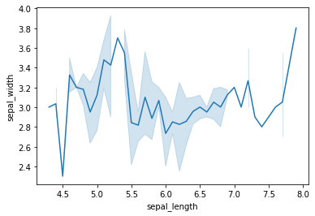

```python
# inport Libraries
import seaborn as sns
import matplotlib.pyplot as plt

# Import DataSet
phool = sns.load_dataset("iris")
phool
##Draw a line plot
sns.lineplot(x="sepal_length",y="sepal_width", data=phool)
plt.show()
```

# Adding title

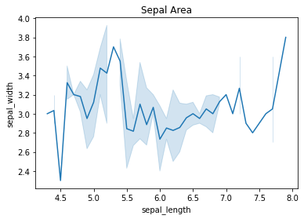

```python
# inport Libraries
import seaborn as sns
import matplotlib.pyplot as plt

# Import DataSet
phool = sns.load_dataset("iris")
phool
##Draw a line plot
sns.lineplot(x="sepal_length",y="sepal_width", data=phool)
plt.title("Sepal Area")
plt.show()
```

# Adding limits

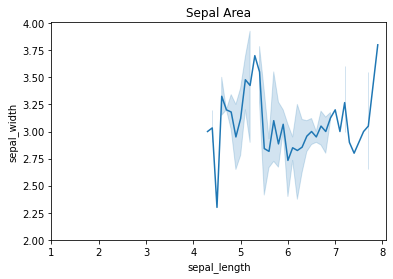

```python
# inport Libraries
import seaborn as sns
import matplotlib.pyplot as plt

# Import DataSet
phool = sns.load_dataset("iris")
phool
##Draw a line plot
sns.lineplot(x="sepal_length",y="sepal_width", data=phool)
plt.title("Sepal Area")
plt.xlim(1)
plt.ylim(2)
plt.show()
```

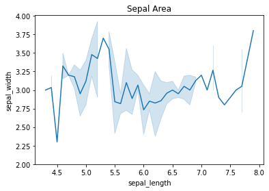

```python
# inport Libraries
import seaborn as sns
import matplotlib.pyplot as plt

# Import DataSet
phool = sns.load_dataset("iris")
phool
##Draw a line plot
sns.lineplot(x="sepal_length",y="sepal_width", data=phool)
plt.title("Sepal Area")
plt.ylim(2)
plt.show()
```

# Set Styles

- Darkgrid
- Whitegrid
- Dark
- white
- Ticks

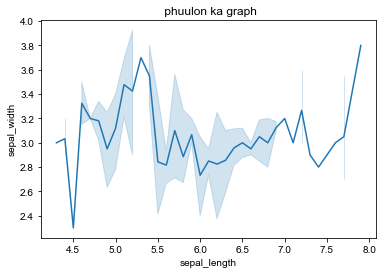

```python
#import library
import seaborn as sns
import matplotlib.pyplot as plt

# import data set
phool=sns.load_dataset("iris")
 #draw a line plot
sns.lineplot(x="sepal_length", y="sepal_width" , data=phool)
plt.title(" phuulon ka graph")
sns.set_style("dark")
plt.show()
```

# Size of Figure

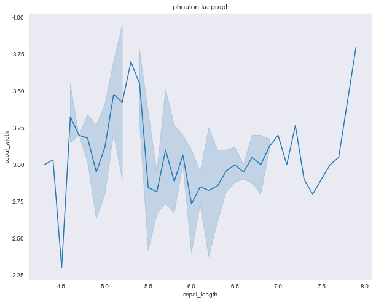

```python
#import library
import seaborn as sns
import matplotlib.pyplot as plt

# import data set
phool=sns.load_dataset("iris")
#Change Size
plt.figure(figsize=(10,8))
 #draw a line plot
sns.lineplot(x="sepal_length", y="sepal_width" , data=phool)
plt.title(" phuulon ka graph")
sns.set_style("dark")
plt.show()
```

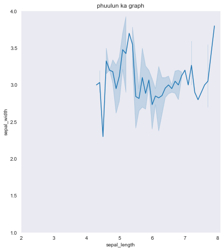

```python
import seaborn as sns
import matplotlib.pyplot as plt
phool=sns.load_dataset("iris")
plt.figure(figsize=(7,8))
sns.lineplot(x="sepal_length", y="sepal_width" , data=phool)
plt.xlim(2)
plt.ylim(1)
plt.title("phuulun ka graph")
sns.set_style("white")
plt.show()
```

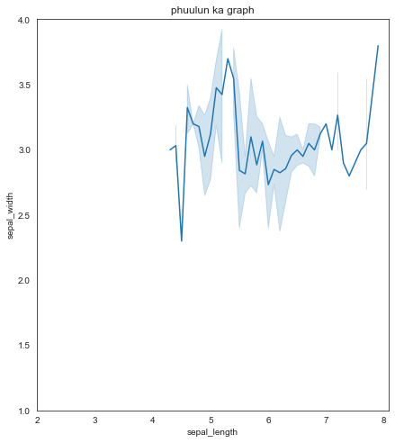

```python
import seaborn as sns
import matplotlib.pyplot as plt
phool=sns.load_dataset("iris")
plt.figure(figsize=(7,8))
sns.lineplot(x="sepal_length", y="sepal_width" , data=phool)
plt.xlim(2)
plt.ylim(1)
plt.title("phuulun ka graph")
sns.set_style("ticks")
plt.show()
```

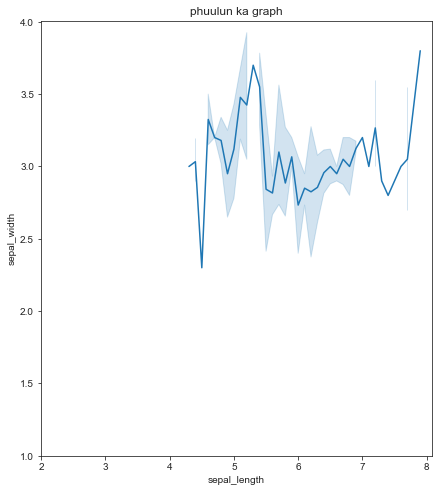

```python
import seaborn as sns
import matplotlib.pyplot as plt
phool=sns.load_dataset("iris")
plt.figure(figsize=(7,8))
sns.lineplot(x="sepal_length", y="sepal_width" , data=phool)
plt.xlim(2)
plt.ylim(1)
plt.title("phuulun ka graph")
sns.set_style("whitegrid")
plt.show()
```

# MOve on To **BArplot**

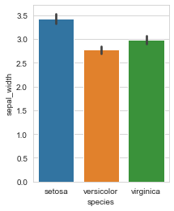

```python
import seaborn as sns
import matplotlib.pyplot as plt

phool=sns.load_dataset("iris")
plt.figure(figsize=(3,4))
sns.barplot(x="species" , y="sepal_width", data=phool)
sns.set_style("white")
plt.show()
```

# Change Order

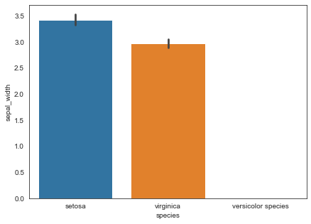

```python
import seaborn as sns
import matplotlib.pyplot as plt

phool=sns.load_dataset("iris")
plt.figure(figsize=(7,5))
sns.barplot(x="species" , y="sepal_width", data=phool , order=["setosa","virginica","versicolor species"])
sns.set_style("dark")
plt.show()
```

# Titanic plot

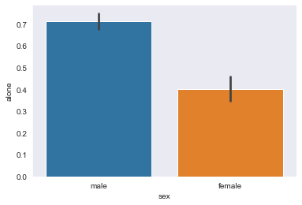

```python
import seaborn as sns
import matplotlib.pyplot as plt

kashti=sns.load_dataset("titanic")
kashti
sns.barplot(x="sex", y="alone" , data=kashti )
plt.show()
```

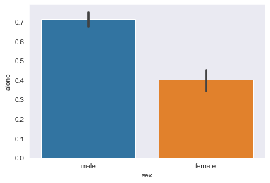

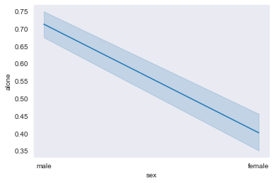

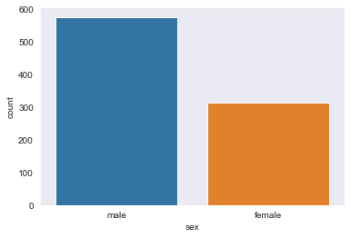

```python
import seaborn as sns
import matplotlib.pyplot as plt

kashti=sns.load_dataset("titanic")
kashti
sns.barplot(x="sex", y="alone" , data=kashti )
plt.show()
sns.lineplot(x="sex", y="alone", data = kashti)
plt.show()
sns.countplot(x="sex", data=kashti)
plt.show()
```

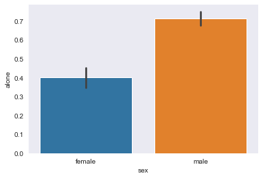

```python
import seaborn as sns
import matplotlib.pyplot as plt

kashti=sns.load_dataset("titanic")
kashti
sns.barplot(x="sex", y="alone" , data=kashti , order=["female", "male"])
plt.show()
```

# Change Colors

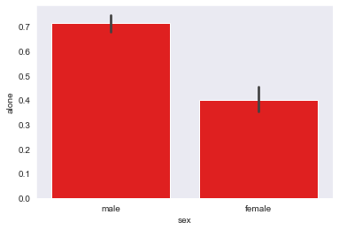

```python
import seaborn as sns
import matplotlib.pyplot as plt

kashti=sns.load_dataset("titanic")
kashti
sns.barplot(x="sex", y="alone" , data=kashti, color="red" )
plt.show()
```

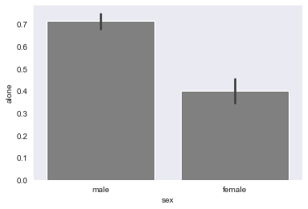

```python
import seaborn as sns
import matplotlib.pyplot as plt

kashti=sns.load_dataset("titanic")
kashti
sns.barplot(x="sex", y="alone" , data=kashti, color="grey" )
plt.show()
```

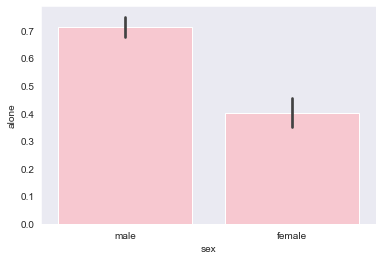

```python
import seaborn as sns
import matplotlib.pyplot as plt

kashti=sns.load_dataset("titanic")
kashti
sns.barplot(x="sex", y="alone" , data=kashti, color="pink" )
plt.show()
```

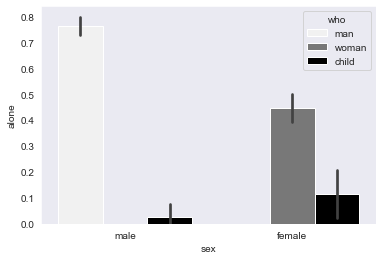

```python
import seaborn as sns
import matplotlib.pyplot as plt

kashti=sns.load_dataset("titanic")
kashti
sns.barplot(x="sex", y="alone", hue="who", data=kashti, color="black"  )
plt.show()
```

# To remove error lines

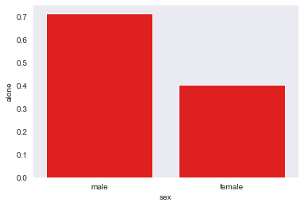

```python
import seaborn as sns
import matplotlib.pyplot as plt

kashti=sns.load_dataset("titanic")
kashti
sns.barplot(x="sex", y="alone" , data=kashti, color="red" , ci=None)
plt.show()
```

# Palette

- to change colour scheme

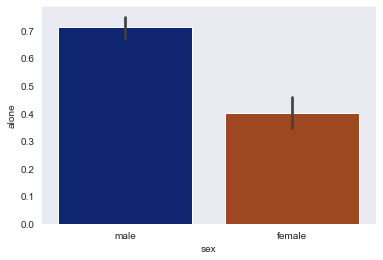

```python
import seaborn as sns
import matplotlib.pyplot as plt

kashti=sns.load_dataset("titanic")
kashti
sns.barplot(x="sex", y="alone" , data=kashti, color="red", palette="dark" )
plt.show()
```